# Detection_0f_Outliers

## Outliers According to Median Method

“mad” gives differences between each value and median, divided by median absolute deviation.

```r
outliers5 <- scores(na.omit(airquality$Ozone) , type = "mad" , prob = 0.95)
ids4 <- which(outliers5  == TRUE)
na.omit(airquality$Ozone)[ids4]
```

```
##  [1] 115 135  77  97  97  85  79  80 108  82  78 122  89 110 168  76 118  84  85
## [20]  96  78  91
```

It finds a lot.

## Mahalanobis Distance

Basically method draws a ellipse with using some properties of data. It uses mean and covariance of data to draw ellipse. After drawing, variables which are out of ellipse called outliers.

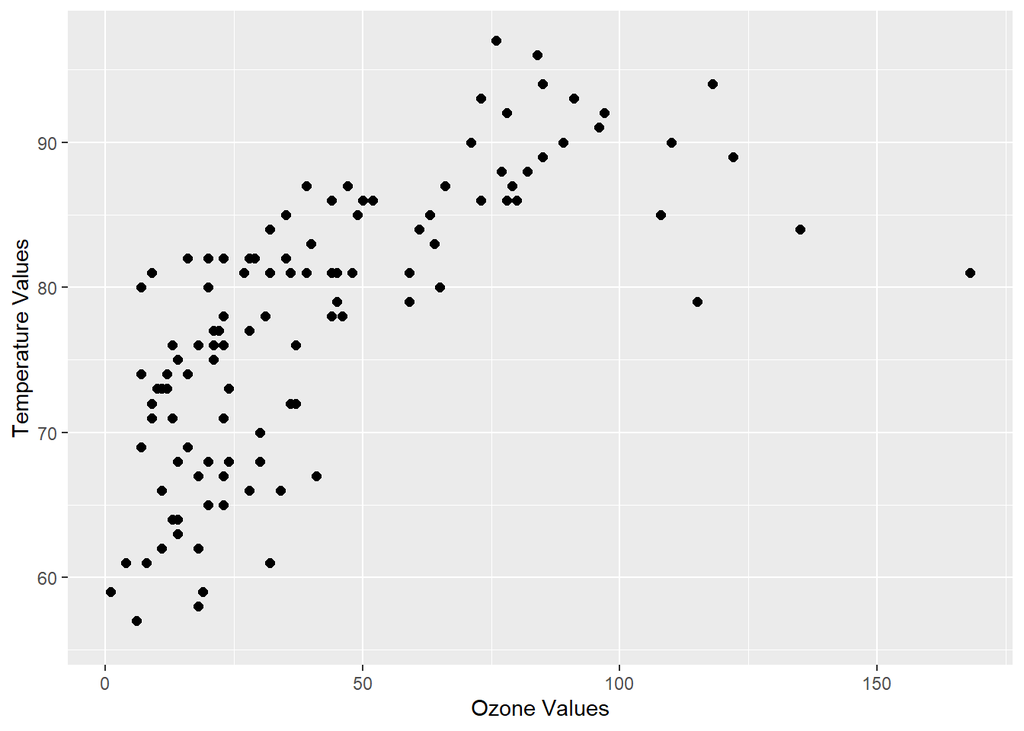

```r
library(ggplot2) # to illustrate graphs
library(car) # to calculate mahalanobis distance
figure <- ggplot(airquality , aes(x = Ozone , y  = Temp)) +
          geom_point(size = 2) +
          xlab("Ozone Values") + ylab("Temperature Values")

figure
```

That is our data.

```r
X <- na.omit(airquality[c("Ozone" , "Temp")]) # data without NA

air.center <- colMeans(X)
air.center
```

```
##    Ozone     Temp
## 42.12931 77.87069
```

```r
air.cov <- cov(X)
air.cov
```

```
##           Ozone      Temp
## Ozone 1088.2005 218.52121
## Temp   218.5212  89.97444
```

```r
radius <- sqrt(qchisq(0.80 , df = 2 ))
radius
```

```
## [1] 1.794123
```

We obtained our necessary values and removed NA values.

```r
ellipse <- ellipse(center = air.center , shape = air.cov , rad = radius ,
        segments = 100 , draw = FALSE)
head(ellipse)
```

```
##              x        y
## [1,] 101.31362 89.75547
## [2,] 101.19683 90.49685
## [3,] 100.84693 91.18840
## [4,] 100.26530 91.82739
## [5,]  99.45423 92.41130
## [6,]  98.41693 92.93782
```

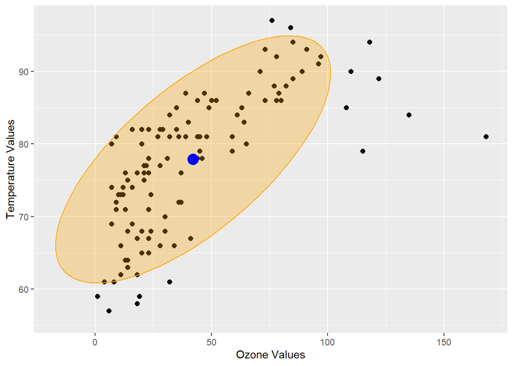

```r
ellipse <- as.data.frame(ellipse)
colnames(ellipse) <- colnames(X)

figure <- figure + geom_polygon(data = ellipse , color = "orange" , fill = "orange" ,
                   alpha = 0.3) +
      geom_point(aes(x = air.center[1] , y = air.center[2]) ,
                 size = 5 , color = "blue")

figure
```

We obtained Mahalonbis distances. Let’s do it via formula.

```r
dist <- mahalanobis(X , center = air.center , cov = air.cov)
head(dist)
```

```
##         1         2         3         4         6         7
## 2.4590777 0.5015840 0.9372617 3.1722308 1.9538256 2.1050539
```

```r
cutoff <- qchisq(p = 0.95 , df = 2)

ids <- which(dist > cutoff)

X[ids ,]
```

```
##     Ozone Temp
## 30    115   79
## 62    135   84
## 99    122   89
## 117   168   81
```

Note: There are many other methods which detect outliers. For instance, Cook’s Distance, Isolation Forest, ODIN, or geometric models etc. In some points , in regression models we are going to use other methods. That is all now. If you have any further interest, you can check the internet.